# Northern sockeye smolt programs In-season update #9 (final)

Fraser Interior Area Sockeye Stock Assessment

2021-05-27

**In-season update for the northern smolt programs 2021. Updates represent preliminary data that have not been verified or processed and are subject to change. Please exercise caution when interpreting raw abundance data as they are not standardized for sampling effort or environmental conditions which may alter abundance patterns.**

# **Background**

Two pilot smolt programs are occurring in the upper Fraser River watershed during the spring of 2021 on the Stellako and Nadleh Rivers. These two programs encounter sockeye smolts from the Nadina (Nadina-Francois-ES) and Stellako (Francois-Fraser-S) sockeye populations. This document will provide updates on both programs separately.

The Stellako River is considered the upstream site and is expected to encounter mostly Nadina sockeye smolts as they exit Francois Lake and travel through Stellako River into Fraser Lake (and beyond). The Stellako program is a collaboration between Carrier Sekani Tribal Council (CSTC) and DFO. The Nadleh river is considered the downstream site and is expected to encounter both Nadina and Stellako sockeye smolts as they exit the Francois-Fraser Lakes system and travel through the Nadleh River on the way to the Nechako River (and beyond). The Nadleh program is a collaboration between Nadleh Whut’en First Nation, the Upper Fraser Fisheries Conservation Alliance (UFFCA), and DFO.

By conducting two programs on the same system, and collecting complementary data at both locations, we will learn more about smolt travel times, growth dynamics, and stock composition at both locations. Work at both locations occurs nightly from 8:00pm (20:00) to 4:00am (04:00). Traps are checked hourly, allowing for approximately 1-hour fishing intervals (trap checks occured at 21:00, 22:00, 23:00, 00:00, 01:00, 02:00 and 03:00 until May 2, at which point checks shifted an hour later to occur hourly from 22:00 to 04:00). Daily fishing is also occurring but only nightly abundance is reported in this update. Smolts encountered are sampled for length, weight, scales (for age), and DNA (for genetic stock identification [GSI] between the Nadina and Stellako populations). Age and GSI results will not be available until the post-season, therefore only length and weight data are reported in this update. DNA samples are obtained from an upper caudal fin clip at Stellako and a lower caudal fin clip at Nadleh.

# **Stellako smolt update**

**Operations**

The Stellako site is using a 6’ Rotary Screw Trap (RST) located in the lower portion of the river at the adult sonar enumeration site and was operational April 11. The first night was a partial shift with four trap checks at 22:00, 23:00, 00:00 and 01:00. Following April 11, crews are following the full night shift schedule (see above for details). The Stellako crew currently consists of 2-3 CSTC Fisheries staff (on a rotating schedule) and 1-2 DFO staff.

**Environmentals**

Water temperatures have remained constant in the Stellako River recently, on average 5.7±1.7 °C (Figure 1), as do air temperatures (9.1±3.4 °C). Water levels have continued to rise slowly but remain constanty high (average of 2.4±0.31 m; Figure 1).

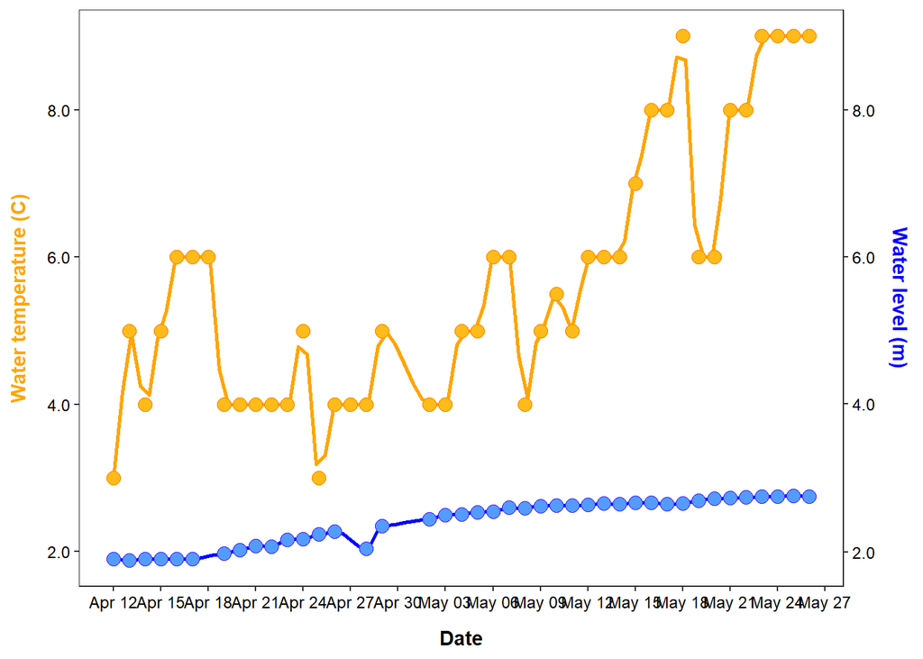

*Figure 1. Water temperature (degrees Celcius) and level (meters) in the Stellako River from Apr 12 to May 26, 2021. Water level data obtained from real-time Environment Canada water data online. The decline on April 27 is likely an effect of Francois Lake buffering the water gauge reading, which is at the top of the Stellako River near Glenannan.*

**Abundance and migration timing**

Catches were 0 for the last nights of fishing at Stellako indicating migration is completely finished (Figure 2a). Variability in hourly catch is still high, but so far suggests that smolts migrate later in the night at Stellako than at Nadleh (Figure 2b).

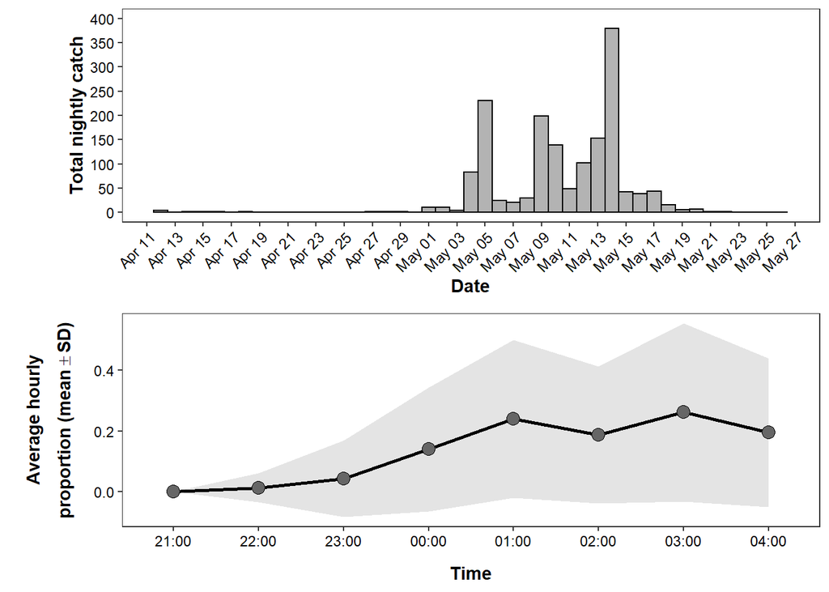

*Figure 2. Stellako River a) total nightly sockeye smolt catch over time, not corrected for effort. b) Sub-sample of the proportion of sockeye smolts composing each hourly catch averaged across days fished (Apr 12 - May 26, 2021). Shading represents standard deviation. Catch times are given based on when smolts were removed from the RST live box. Dates are given based on when the RST was closed.*

**Biological data**

Smolts encountered at the Stellako River site are large, on average 107.6±10 mm and 11.4±4.7 g.

**Mark-recapture release cohorts**

Mark-recapture trials to evaluate trap efficiency have begun at Stellako (Table 1).

*Table 1. Mark-release cohorts released in the Stellako River*

| Date | Cohort size | Mark type |
| --- | --- | --- |
| May 5 | 114 | Upper caudal clip |
| May 9 | 100 | Upper caudal clip |
| May 14 | 201 | Upper caudal clip |

# **Nadleh smolt update**

**Operations**

The Nadleh program is using an 8’ RST located at the Nadleh bridge, about half-way down the river (above the rapids) and was operational April 10. The first night was a partial shift with three trap checks at 23:00, 00:00 and 01:00. Following April 11, crews are working the full night shift (see above for details). The Nadleh crew currently consists of 2-3 Nadleh Whut’en staff (on a rotational shift) and 1-2 DFO staff.

**Environmentals**

Water temperatures have remained constant in the Nadleh River lately, on average 6.7±2.9 °C, with average air temperatures at 5.7±4.6 °C. Water levels have also remained constant recently (average of 2±0.32 m, Figure 3).

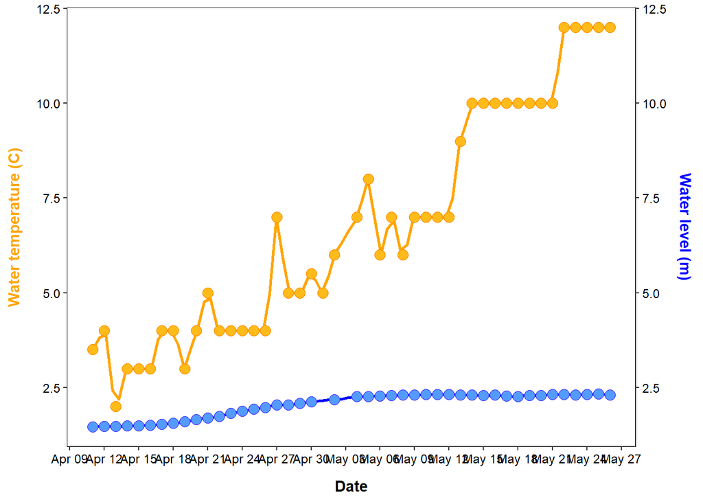

*Figure 3. Water temperature (degrees Celcius) and level (meters) in the Nadleh River from Apr 11 to May 26, 2021. Water level data obtained from real-time Environment Canada water data online.*

**Abundance and migration timing**

Catches have declined to low numbers at Nadleh; the final night of fishing yielded approximately 60 smolts which suggests migration is essentially over (Figure 4a). Peak nightly migration appears to be between 10pm and 1am, as it has been historically (Figure 4b).

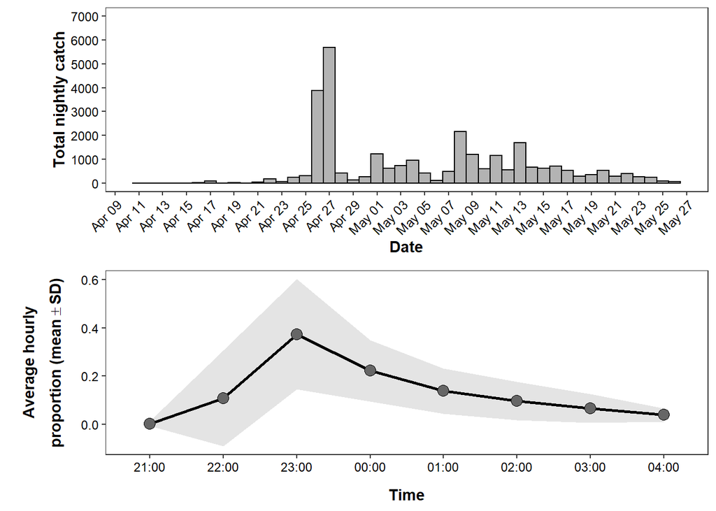

*Figure 4. Nadleh River a) total nightly sockeye smolt catch over time, not corrected for effort. b) Sub-sample of the proportion of sockeye smolts composing each hourly catch averaged across days fished (Apr 11 - May 26, 2021). Shading represents standard deviation. Catch times are given based on when smolts were removed from the RST live box. Dates are given based on when the RST was closed.*

**Biological data**

Smolts encountered at the Nadleh River are slightly smaller than those caught at Stellako, on average 103.6±13 mm and 11.6±8.9 g.

**Mark-recapture release cohorts**

Mark-recapture trials to evaluate trap efficiency have begun at Nadleh and will continue as long as smolt abundance lasts (Table 2).

*Table 2. Mark-release cohorts released in the Nadleh River*

| Date | Cohort size | Mark type |
| --- | --- | --- |
| April 28 | 421 | Lower caudal clip |
| May 1 | 1220 | Lower caudal clip |
| May 10 | 546 | Lower caudal clip |
| May 19 | 365 | Lower caudal clip |

This is the last update for 2021.